# a2_task2_dani_sclafani

Danielle Sclafani

2/6/2021

```r
palmetto <- read_csv(here("data", "palmetto.csv")) %>%
  clean_names() %>%
  select(height, length, width, green_lvs, species) %>%
  mutate(species_name = case_when(
    species == 1 ~ "Serenoa repens",
    species == 2 ~ "Sabal etonia"
  ))
```

## Data Visualizations

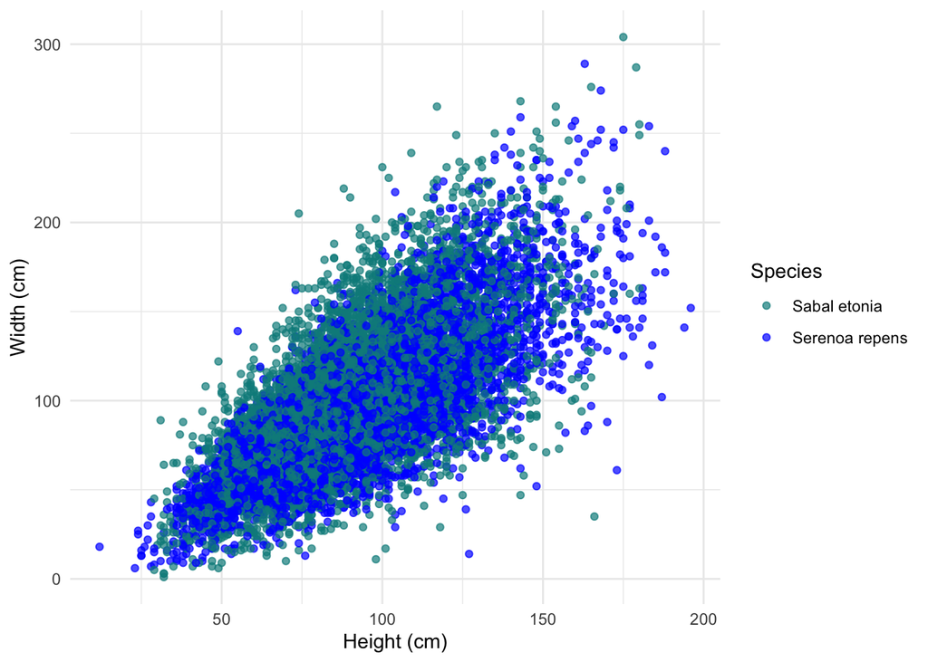

Figure 1.0: Distribution of *S. etonia* and *S. repens* canopy heights (cm) versus canopy width (cm)

```r
# data visualization of height comparison

ggplot(data = palmetto, aes(x = height, y = width)) + geom_point(aes(color = species_name), alpha = 0.7) +
                                                          scale_color_manual(values = c("cyan4", "blue"))  +
  theme_minimal()+
  labs(x = "Height (cm)", y ="Width (cm)", color = "Species")
```

The two species of trees, *S. etonia* and *S. repens* have very similar distributions of height (cm) and width (cm), however, there seems to be more *S. repens* trending towards a smaller canopy width and *S. etonia* having a larger canopy width.

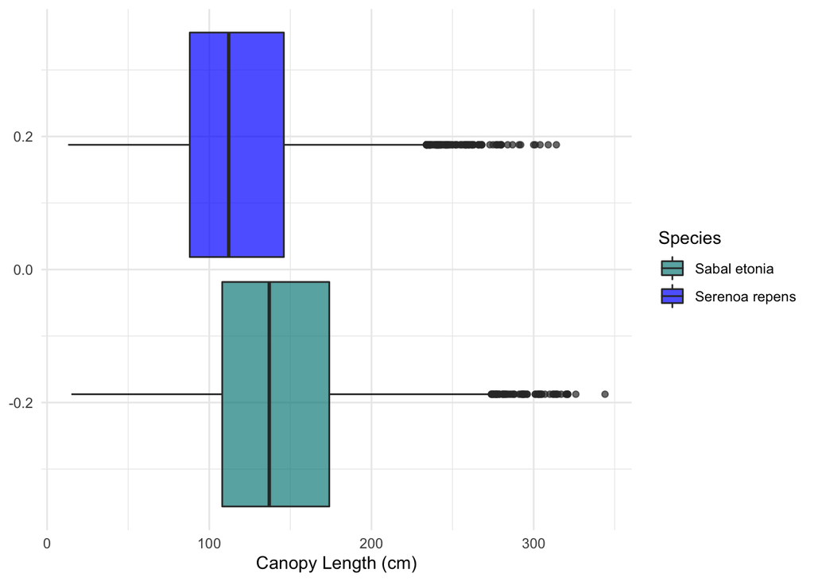

Figure 2.0: Comparison of canopy Length (cm) of *S. etonia* and *S. repens*

```r
ggplot(data = palmetto, aes(x = length)) + geom_boxplot(aes(fill = species_name), alpha = 0.7) +
                                                          scale_fill_manual(values = c("cyan4", "blue")) +
  theme_minimal() +
  labs(x = "Canopy Length (cm)", fill = "Species")
```

The overall distribution of *S. entonia* and *S. repens* overlap pretty significantly however, the mean canopy length (cm) of *S. entonia* is slightly larger than the mean canopy length (cm) of *S. repens*.

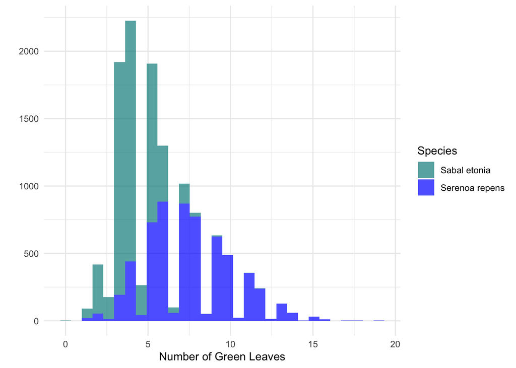

Figure 3: Comparison of the number of green leaves present on *S. etonia* and *S. repens* trees.

```r
# data visualization exploring number of green leaves on each species

ggplot(data = palmetto, aes(x = green_lvs)) + geom_histogram(aes(fill = species_name), alpha = 0.7) +
  scale_fill_manual(values = c("cyan4", "blue")) +
  theme_minimal()+
  labs(x = "Number of Green Leaves", fill = "Species", y = " ")
```

The distribution of the number of green leaves on each tree species appears to provide some insight into how the trees may be identified. *S. etonia* appears to have a lower mean number of leaves than *S. repens*. The distribution of the number of leaves for *S. repens* is larger than that of *S. etonia*.

## Binary Logistic Regression

##### Results of Binary Logistic Regression

```r
#made the species into factors, Sabal etonia = 0, Serenoa repens = 1, because Serenoa repens is the 1 factor, the regression model will show us the probability that it is Serenoa repens

palm_fact <- palmetto %>%
  mutate(species_name = fct_drop(species_name))

#making the binary logistic regression
palm_blr <- glm(species_name ~ height + length + green_lvs + width,
                data = palm_fact,
                family = "binomial")

# looking at the outcomes

summary(palm_blr)
```

```
##
## Call:
## glm(formula = species_name ~ height + length + green_lvs + width,
##     family = "binomial", data = palm_fact)
##
## Deviance Residuals:
##     Min       1Q   Median       3Q      Max
## -4.7828  -0.2681  -0.0054   0.1725   3.3964
##
## Coefficients:
##              Estimate Std. Error z value Pr(>|z|)
## (Intercept) -3.226685   0.142071  -22.71   <2e-16 ***
## height       0.029217   0.002306   12.67   <2e-16 ***
## length      -0.045823   0.001866  -24.56   <2e-16 ***
## green_lvs    1.908475   0.038863   49.11   <2e-16 ***
## width       -0.039443   0.002100  -18.78   <2e-16 ***
## ---
## Signif. codes:  0 '***' 0.001 '**' 0.01 '*' 0.05 '.' 0.1 ' ' 1
##
## (Dispersion parameter for binomial family taken to be 1)
##
##     Null deviance: 17005.5  on 12266  degrees of freedom
## Residual deviance:  5184.6  on 12262  degrees of freedom
##   (193 observations deleted due to missingness)
## AIC: 5194.6
##
## Number of Fisher Scoring iterations: 7
```

```r
#table prep
tidy_palm_blr <- broom::tidy(palm_blr)
```

```r
# making a table of blr results

kable(tidy_palm_blr, caption = "Palmetto Binary Logistic Regression Results") %>%
  kable_classic_2(full_width = F) %>%
  kable_styling(bootstrap_options = c("striped", "hover", "condensed"))
```

Palmetto Binary Logistic Regression Results

| term | estimate | std.error | statistic | p.value |
| --- | --- | --- | --- | --- |
| (Intercept) | -3.2266851 | 0.1420708 | -22.71180 | 0 |
| height | 0.0292173 | 0.0023061 | 12.66984 | 0 |
| length | -0.0458233 | 0.0018661 | -24.55600 | 0 |
| green_lvs | 1.9084747 | 0.0388634 | 49.10728 | 0 |
| width | -0.0394434 | 0.0021000 | -18.78227 | 0 |

```r
# getting the probabilities, probability that something is a S. repens is in the .fitted column
blr_fitted <- palm_blr %>%
  broom::augment(type.predict = "response")
```

```r
# adding a column that says the species the observation should be based on the model
palm_prob <- blr_fitted %>%
  mutate(predicted_species = case_when(
    .fitted >= 0.5 ~ "Serenoa repens",
    .fitted < 0.5 ~ "Sabal etonia"
  ))

#using case when
palm_accurate <- palm_prob %>%
  mutate(accurate = case_when(
    species_name == predicted_species ~ "Accurate",
    species_name != predicted_species ~ "Inaccurate"))

#palm_accurate table
palm_table <- palm_accurate %>%
  group_by(species_name, accurate) %>%
  count()
```

Table 2.0 Displays the accuracy of the Binary Logistic Model to determine the species of tree based on the four variables canopy height (cm), canopy width (cm), canopy length (cm), and the number of green leaves. The percent of each species accurately and inaccurately predicted by the model are provided. The counts of accurate and inaccurate predictions are also included in parentheses.

```r
#percent attempt
percent_attempt <- palm_table %>%
  pivot_wider(species_name, names_from = "accurate",
              values_from = "n") %>%
  adorn_percentages() %>%
  adorn_pct_formatting(digits = 2) %>%
  adorn_ns() %>%
  rename(Species = species_name)

percent_attempt %>%
  kbl(caption = "Percentage and Occurence of Binary Logistic Model predicting the species Accurately and Inaccurately") %>%
  kable_classic_2(full_width = F, html_font = "Cambria")
```

Percentage and Occurence of Binary Logistic Model predicting the species Accurately and Inaccurately

| Species | Accurate | Inaccurate |
| --- | --- | --- |
| Sabal etonia | 92.62% (5701) | 7.38% (454) |
| Serenoa repens | 90.77% (5548) | 9.23% (564) |

Data Citation: Abrahamson, W.G. 2019. Survival, growth and biomass estimates of two dominant palmetto species of south-central Florida from 1981 - 2017, ongoing at 5-year intervals ver 1. Environmental Data Initiative. https://doi.org/10.6073/pasta/f2f96ec76fbbd4b9db431c79a770c4d5